# ETC3550: Applied forecasting for business and economics

OTexts.org/fpp2/

## The linear model with time series

## Multiple regression and forecasting

- \(y_t\) is the variable we want to predict: the ``response’’ variable
- Each \(x_{j,t}\) is numerical and is called a ``predictor’’. They are usually assumed to be known for all past and future times.
- The coefficients \(\beta_1,\dots,\beta_k\) measure the effect of each predictor after taking account of the effect of all other predictors in the model.

That is, the coefficients measure the **marginal effects**.

- \(\varepsilon_t\) is a white noise error term

## Example: US consumption expenditure

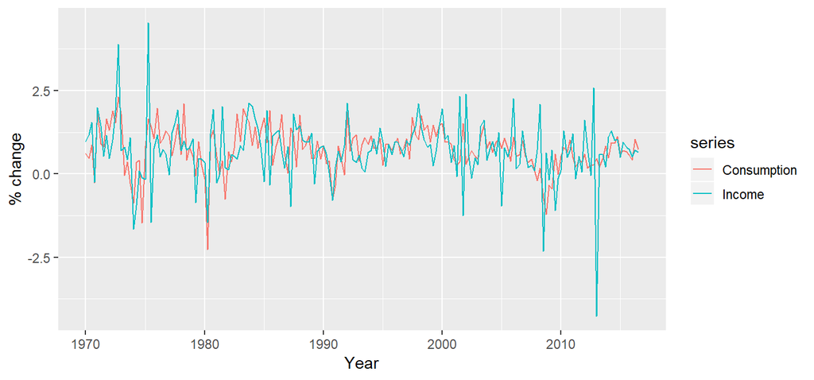

```r
autoplot(uschange[,c("Consumption","Income")]) +
  ylab("% change") + xlab("Year")
```

## Example: US consumption expenditure

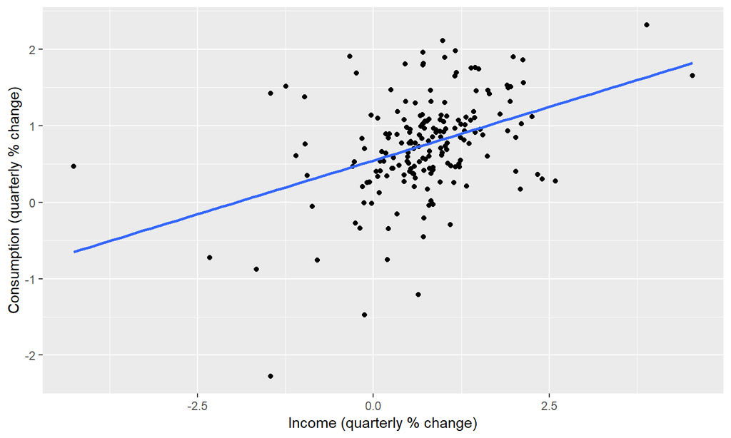

## Example: US consumption expenditure

```r
tslm(Consumption ~ Income, data=uschange) %>% summary
```

```
##
## Call:
## tslm(formula = Consumption ~ Income, data = uschange)
##
## Residuals:
##      Min       1Q   Median       3Q      Max
## -2.40845 -0.31816  0.02558  0.29978  1.45157
##
## Coefficients:
##             Estimate Std. Error t value Pr(>|t|)
## (Intercept)  0.54510    0.05569   9.789  < 2e-16 ***
## Income       0.28060    0.04744   5.915 1.58e-08 ***
## ---
## Signif. codes:  0 '***' 0.001 '**' 0.01 '*' 0.05 '.' 0.1 ' ' 1
##
## Residual standard error: 0.6026 on 185 degrees of freedom
## Multiple R-squared:  0.159,  Adjusted R-squared:  0.1545
## F-statistic: 34.98 on 1 and 185 DF,  p-value: 1.577e-08
```

## Example: US consumption expenditure

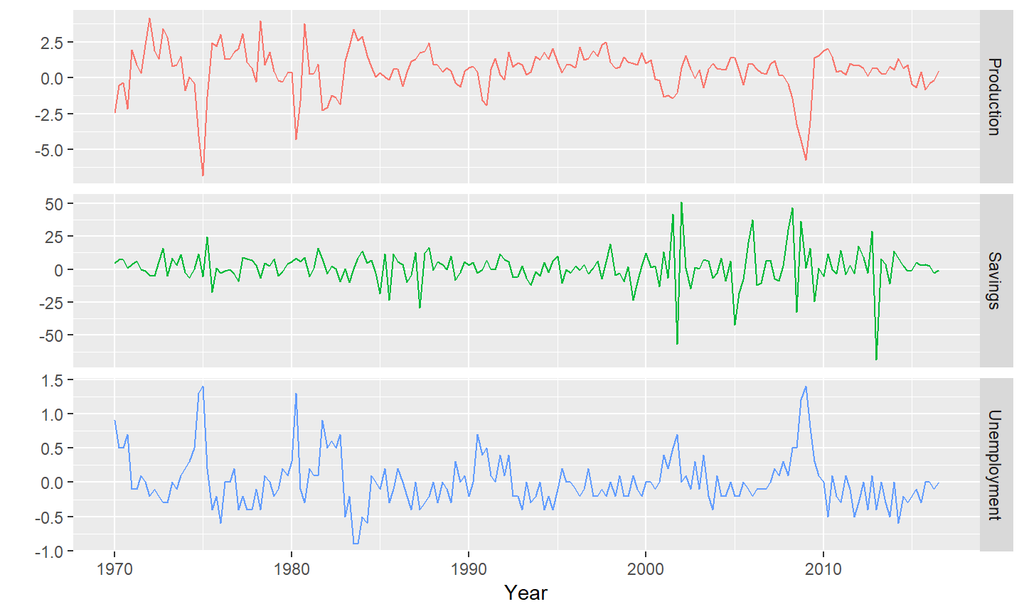

## Example: US consumption expenditure

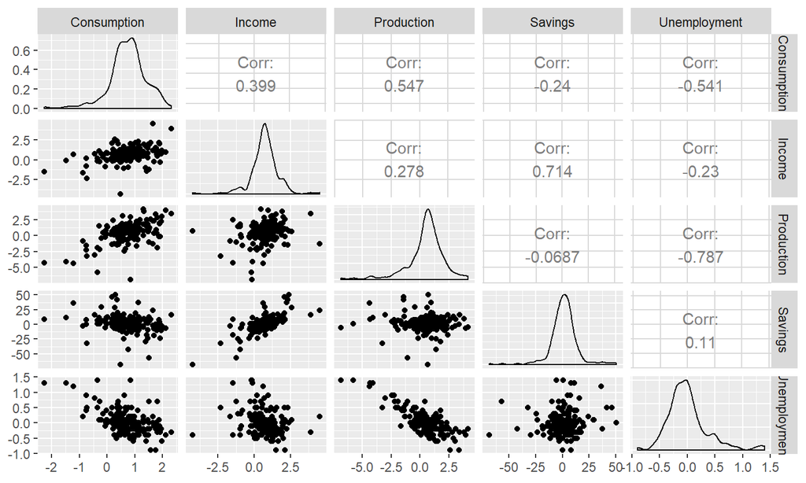

## Example: US consumption expenditure

```r
fit.consMR <- tslm(
  Consumption ~ Income + Production + Unemployment + Savings,
  data=uschange)
summary(fit.consMR)
```

```
##
## Call:
## tslm(formula = Consumption ~ Income + Production + Unemployment +
##     Savings, data = uschange)
##
## Residuals:
##      Min       1Q   Median       3Q      Max
## -0.88296 -0.17638 -0.03679  0.15251  1.20553
##
## Coefficients:
##              Estimate Std. Error t value Pr(>|t|)
## (Intercept)   0.26729    0.03721   7.184 1.68e-11 ***
## Income        0.71449    0.04219  16.934  < 2e-16 ***
## Production    0.04589    0.02588   1.773   0.0778 .
## Unemployment -0.20477    0.10550  -1.941   0.0538 .
## Savings      -0.04527    0.00278 -16.287  < 2e-16 ***
## ---
## Signif. codes:  0 '***' 0.001 '**' 0.01 '*' 0.05 '.' 0.1 ' ' 1
##
## Residual standard error: 0.3286 on 182 degrees of freedom
## Multiple R-squared:  0.754,  Adjusted R-squared:  0.7486
## F-statistic: 139.5 on 4 and 182 DF,  p-value: < 2.2e-16
```

## Example: US consumption expenditure

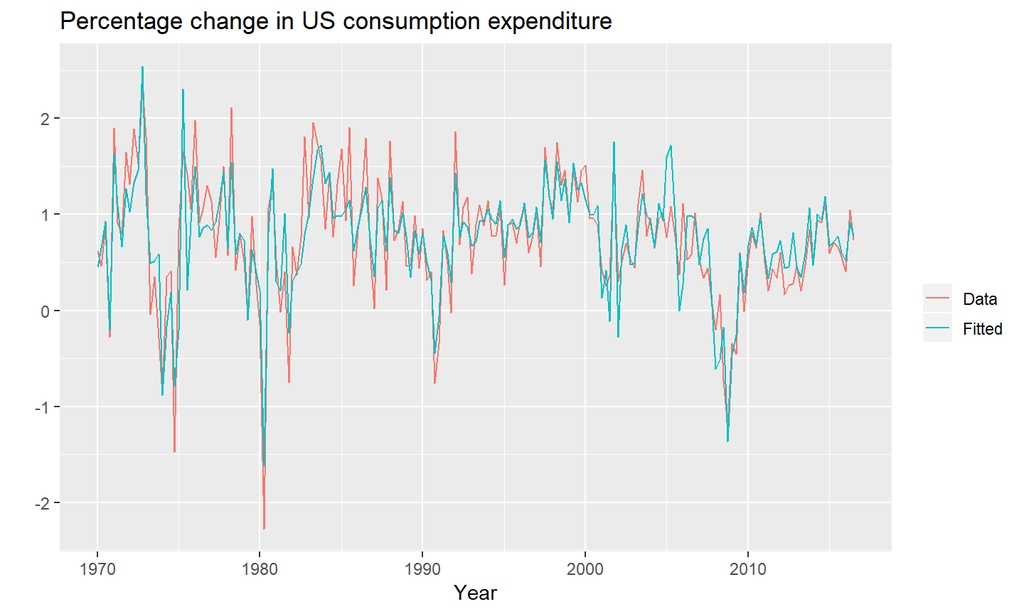

## Example: US consumption expenditure

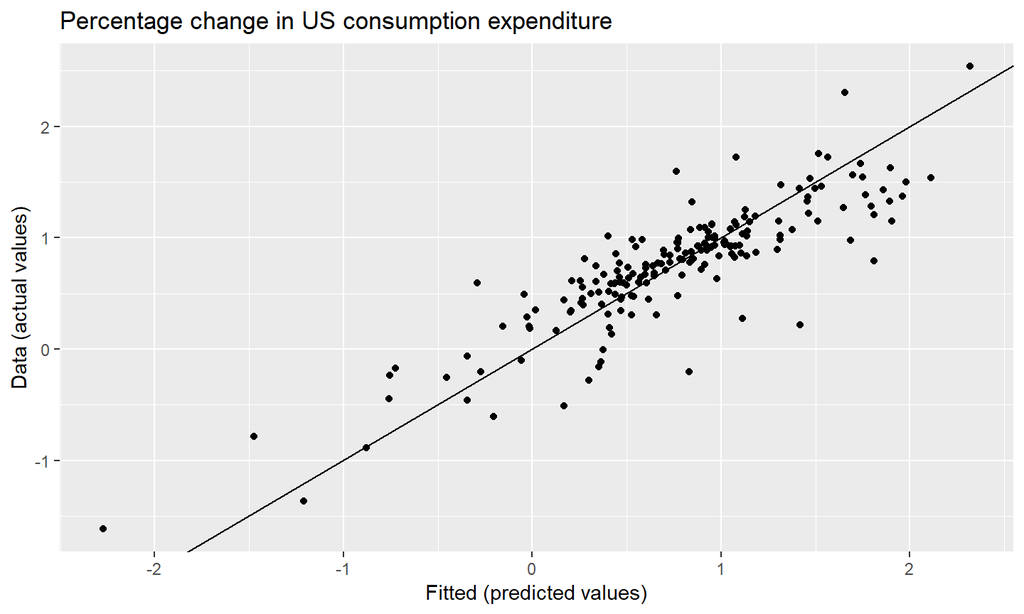

## Example: US consumption expenditure

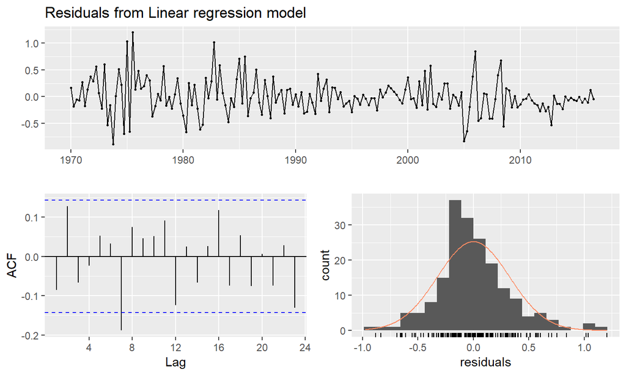

## Residual diagnostics

## Multiple regression and forecasting

For forecasting purposes, we require the following assumptions:

- \(\varepsilon_t\) are uncorrelated and zero mean
- \(\varepsilon_t\) are uncorrelated with each \(x_{j,t}\).

It is **useful** to also have \(\varepsilon_t \sim \text{N}(0,\sigma^2)\) when producing prediction intervals or doing statistical tests.

## Residual plots

Useful for spotting outliers and whether the linear model was appropriate.

- Scatterplot of residuals \(\varepsilon_t\) against each predictor \(x_{j,t}\).
- Scatterplot residuals against the fitted values \(\hat y_t\)
- Expect to see scatterplots resembling a horizontal band with no values too far from the band and no patterns such as curvature or increasing spread.

## Residual patterns

- If a plot of the residuals vs any predictor in the model shows a pattern, then the relationship is nonlinear.
- If a plot of the residuals vs any predictor **not** in the model shows a pattern, then the predictor should be added to the model.
- If a plot of the residuals vs fitted values shows a pattern, then there is heteroscedasticity in the errors. (Could try a transformation.)

## Breusch-Godfrey test

**OLS regression:** \[ y_{t}=\beta_{0}+\beta_{1}x_{t,1}+\dots+\beta_{k}x_{t,k}+u_{t} \] **Auxiliary regression:** \[ {\hat {u}}_{t}=\beta_{0}+\beta_{1}x_{t,1}+\dots+\beta_{k}x_{t,k}+\rho_{1}{\hat {u}}_{t-1}+\dots +\rho_{p}{\hat {u}}_{t-p}+\varepsilon_{t} \]

If \(R^{2}\) statistic is calculated for this model, then \[ (T-p)R^{2}\,\sim \,\chi_{p}^{2}, \] when there is no serial correlation up to lag \(p\), and \(T=\) length of series.

- Breusch-Godfrey test better than Ljung-Box for regression models.

## US consumption again

```
##
##  Breusch-Godfrey test for serial correlation of order up to 8
##
## data:  Residuals from Linear regression model
## LM test = 14.874, df = 8, p-value = 0.06163
```

### If the model fails the Breusch-Godfrey test

- The forecasts are not wrong, but have higher variance than they need to.
- There is information in the residuals that we should exploit.
- This is done with a regression model with ARMA errors.

## Some useful predictors for linear models

## Trend

**Linear trend** \[ x_t = t \]

- \(t=1,2,\dots,T\)
- Strong assumption that trend will continue.

## Dummy variables

## Dummy variables

## Beware of the dummy variable trap!

- Using one dummy for each category gives too many dummy variables!
- The regression will then be singular and inestimable.
- Either omit the constant, or omit the dummy for one category.
- The coefficients of the dummies are relative to the omitted category.

## Uses of dummy variables

**Seasonal dummies**

- For quarterly data: use 3 dummies
- For monthly data: use 11 dummies
- For daily data: use 6 dummies
- What to do with weekly data?

**Outliers**

- If there is an outlier, you can use a dummy variable (taking value 1 for that observation and 0 elsewhere) to remove its effect.

**Public holidays**

- For daily data: if it is a public holiday, dummy=1, otherwise dummy=0.

## Beer production revisited

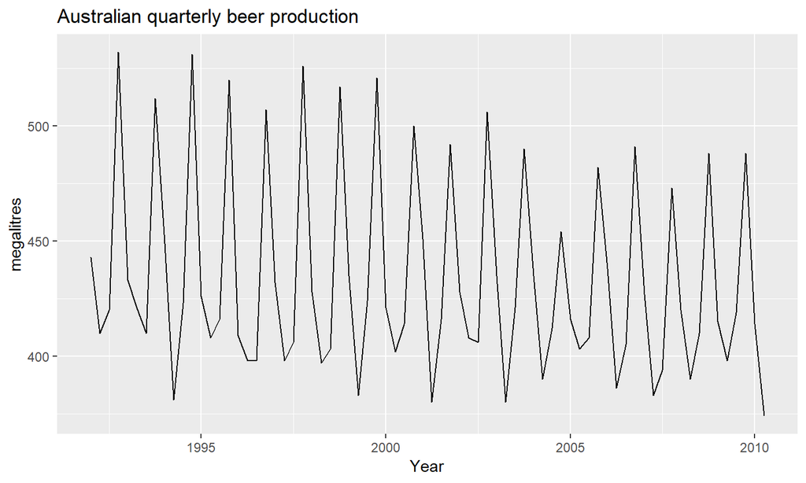

## Beer production revisited

- \(d_{i,t} = 1\) if \(t\) is quarter \(i\) and 0 otherwise.

## Beer production revisited

```r
fit.beer <- tslm(beer ~ trend + season)
summary(fit.beer)
```

```
##
## Call:
## tslm(formula = beer ~ trend + season)
##
## Residuals:
##     Min      1Q  Median      3Q     Max
## -42.903  -7.599  -0.459   7.991  21.789
##
## Coefficients:
##              Estimate Std. Error t value Pr(>|t|)
## (Intercept) 441.80044    3.73353 118.333  < 2e-16 ***
## trend        -0.34027    0.06657  -5.111 2.73e-06 ***
## season2     -34.65973    3.96832  -8.734 9.10e-13 ***
## season3     -17.82164    4.02249  -4.430 3.45e-05 ***
## season4      72.79641    4.02305  18.095  < 2e-16 ***
## ---
## Signif. codes:  0 '***' 0.001 '**' 0.01 '*' 0.05 '.' 0.1 ' ' 1
##
## Residual standard error: 12.23 on 69 degrees of freedom
## Multiple R-squared:  0.9243, Adjusted R-squared:  0.9199
## F-statistic: 210.7 on 4 and 69 DF,  p-value: < 2.2e-16
```

## Beer production revisited

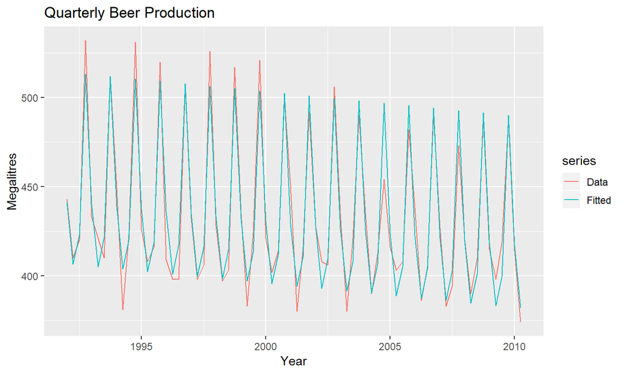

## Beer production revisited

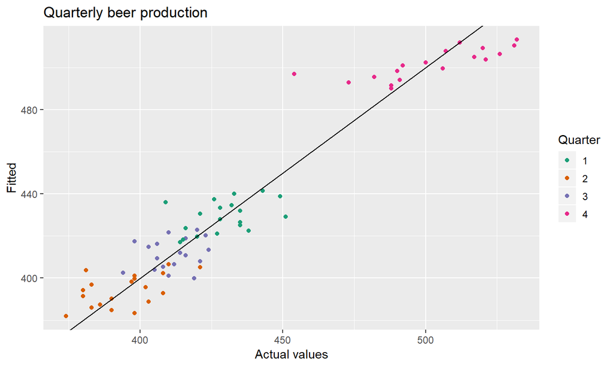

## Beer production revisited

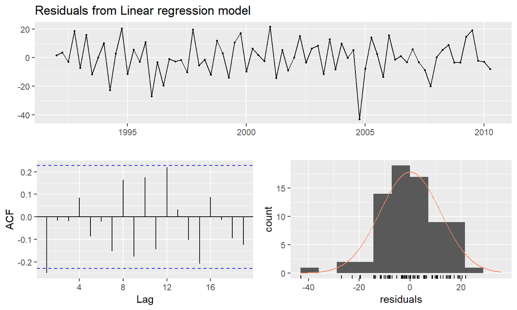

## Beer production revisited

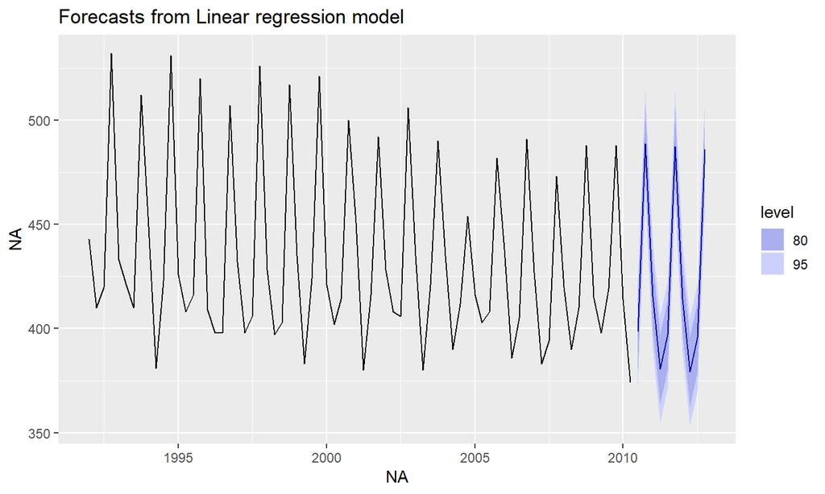

## Fourier series

Periodic seasonality can be handled using pairs of Fourier terms: \[ s_{k}(t) = \sin\left(\frac{2\pi k t}{m}\right)\qquad c_{k}(t) = \cos\left(\frac{2\pi k t}{m}\right) \] \[ y_t = a + bt + \sum_{k=1}^K \left[\alpha_k s_k(t) + \beta_k c_k(t)\right] + \varepsilon_t\]

- Every periodic function can be approximated by sums of sin and cos terms for large enough \(K\).
- Choose \(K\) by minimizing AICc.
- Called “harmonic regression”

```r
fit <- tslm(y ~ trend + fourier(y, K))
```

## Harmonic regression: beer production

```r
fourier.beer <- tslm(beer ~ trend + fourier(beer, K=2))
summary(fourier.beer)
```

```
##
## Call:
## tslm(formula = beer ~ trend + fourier(beer, K = 2))
##
## Residuals:
##     Min      1Q  Median      3Q     Max
## -42.903  -7.599  -0.459   7.991  21.789
##
## Coefficients:
##                           Estimate Std. Error t value Pr(>|t|)
## (Intercept)              446.87920    2.87321 155.533  < 2e-16 ***
## trend                     -0.34027    0.06657  -5.111 2.73e-06 ***
## fourier(beer, K = 2)S1-4   8.91082    2.01125   4.430 3.45e-05 ***
## fourier(beer, K = 2)C1-4  53.72807    2.01125  26.714  < 2e-16 ***
## fourier(beer, K = 2)C2-4  13.98958    1.42256   9.834 9.26e-15 ***
## ---
## Signif. codes:  0 '***' 0.001 '**' 0.01 '*' 0.05 '.' 0.1 ' ' 1
##
## Residual standard error: 12.23 on 69 degrees of freedom
## Multiple R-squared:  0.9243, Adjusted R-squared:  0.9199
## F-statistic: 210.7 on 4 and 69 DF,  p-value: < 2.2e-16
```

## Intervention variables

**Spikes**

- Equivalent to a dummy variable for handling an outlier.

**Steps**

- Variable takes value 0 before the intervention and 1 afterwards.

**Change of slope**

- Variables take values 0 before the intervention and values \(\{1,2,3,\dots\}\) afterwards.

## Holidays

**For monthly data**

- Christmas: always in December so part of monthly seasonal effect
- Easter: use a dummy variable \(v_t=1\) if any part of Easter is in that month, \(v_t=0\) otherwise.
- Ramadan and Chinese new year similar.

## Trading days

With monthly data, if the observations vary depending on how many different types of days in the month, then trading day predictors can be useful.

## Distributed lags

Lagged values of a predictor.

Example: \(x\) is advertising which has a delayed effect

## Nonlinear trend

**Piecewise linear trend with bend at \(\tau\)**

**Quadratic or higher order trend** \[ x_{1,t} =t,\quad x_{2,t}=t^2,\quad \dots \]

## Example: Boston marathon winning times

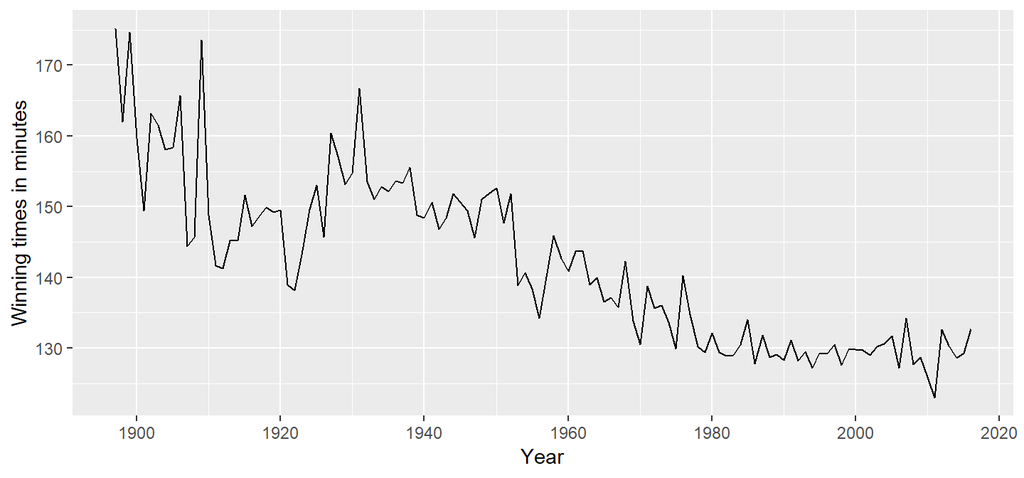

```r
autoplot(marathon) +
  xlab("Year") +  ylab("Winning times in minutes")
```

```r
fit.lin <- tslm(marathon ~ trend)
```

## Example: Boston marathon winning times

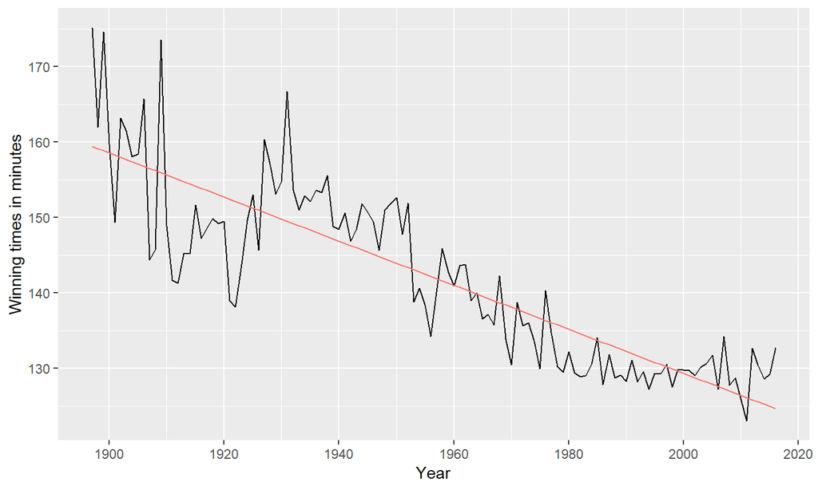

## Example: Boston marathon winning times

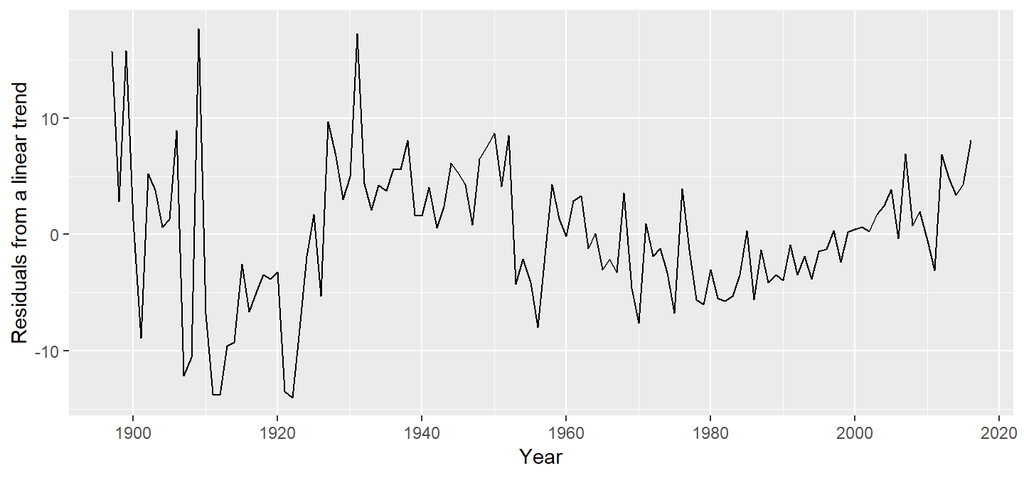

```r
autoplot(residuals(fit.lin)) +
    xlab("Year") + ylab("Residuals from a linear trend")
```

## Example: Boston marathon winning times

```r
# Linear trend
fit.lin <- tslm(marathon ~ trend)
fcasts.lin <- forecast(fit.lin, h=10)

# Exponential trend
fit.exp <- tslm(marathon ~ trend, lambda = 0)
fcasts.exp <- forecast(fit.exp, h=10)

# Piecewise linear trend
t.break1 <- 1940
t.break2 <- 1980
t <- time(marathon)
t1 <- ts(pmax(0, t-t.break1), start=1897)
t2 <- ts(pmax(0, t-t.break2), start=1897)
fit.pw <- tslm(marathon ~ t + t1 + t2)
t.new <- t[length(t)] + seq(10)
t1.new <- t1[length(t1)] + seq(10)
t2.new <- t2[length(t2)] + seq(10)
newdata <- cbind(t=t.new, t1=t1.new, t2=t2.new) %>%
  as.data.frame
fcasts.pw <- forecast(fit.pw, newdata = newdata)
```

## Example: Boston marathon winning times

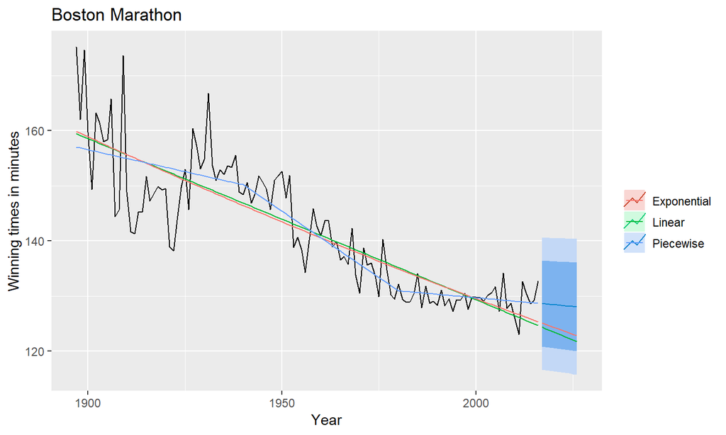

## Example: Boston marathon winning times

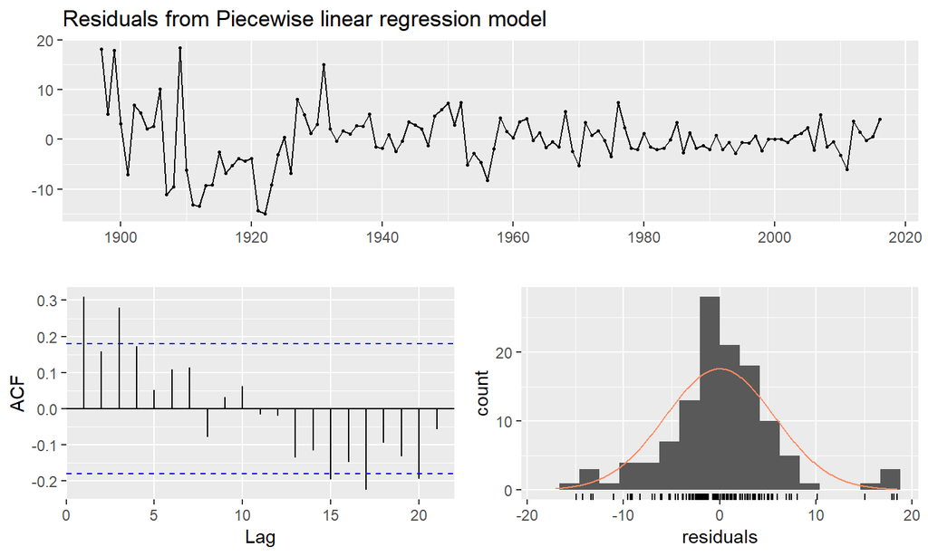

## Interpolating splines

## Interpolating splines

## Interpolating splines

## Interpolating splines

- Parameters constrained so that \(f(x)\) is continuous.
- Further constraints imposed to give continuous derivatives.

## General linear regression splines

- Let \(\kappa_1<\kappa_2<\cdots<\kappa_K\) be ``knots’’ in interval \((a,b)\).
- Let \(x_1=x\), \(x_j = (x-\kappa_{j-1})_+\) for \(j=2,\dots,K+1\).
- Then the regression is piecewise linear with bends at the knots.

## General cubic splines

- Let \(x_1=x\), \(x_2 = x^2\), \(x_3=x^3\), \(x_j = (x-\kappa_{j-3})_+^3\) for \(j=4,\dots,K+3\).
- Then the regression is piecewise cubic, but smooth at the knots.
- Choice of knots can be difficult and arbitrary.
- Automatic knot selection algorithms very slow.

## Example: Boston marathon winning times

```r
# Spline trend
library(splines)
t <- time(marathon)
fit.splines <- lm(marathon ~ ns(t, df=6))
summary(fit.splines)
```

```
##
## Call:
## lm(formula = marathon ~ ns(t, df = 6))
##
## Residuals:
##      Min       1Q   Median       3Q      Max
## -13.0028  -2.5722   0.0122   2.1242  21.5681
##
## Coefficients:
##                Estimate Std. Error t value Pr(>|t|)
## (Intercept)     168.447      2.086  80.743  < 2e-16 ***
## ns(t, df = 6)1   -6.948      2.688  -2.584    0.011 *
## ns(t, df = 6)2  -28.856      3.416  -8.448 1.16e-13 ***
## ns(t, df = 6)3  -35.081      3.045 -11.522  < 2e-16 ***
## ns(t, df = 6)4  -32.563      2.652 -12.279  < 2e-16 ***
## ns(t, df = 6)5  -64.847      5.322 -12.184  < 2e-16 ***
## ns(t, df = 6)6  -21.002      2.403  -8.741 2.46e-14 ***
## ---
## Signif. codes:  0 '***' 0.001 '**' 0.01 '*' 0.05 '.' 0.1 ' ' 1
##
## Residual standard error: 4.834 on 113 degrees of freedom
## Multiple R-squared:  0.8418, Adjusted R-squared:  0.8334
## F-statistic: 100.2 on 6 and 113 DF,  p-value: < 2.2e-16
```

```r
fits <- ts(fitted(fit.splines))
tsp(fits) <- tsp(marathon)
```

## Example: Boston marathon winning times

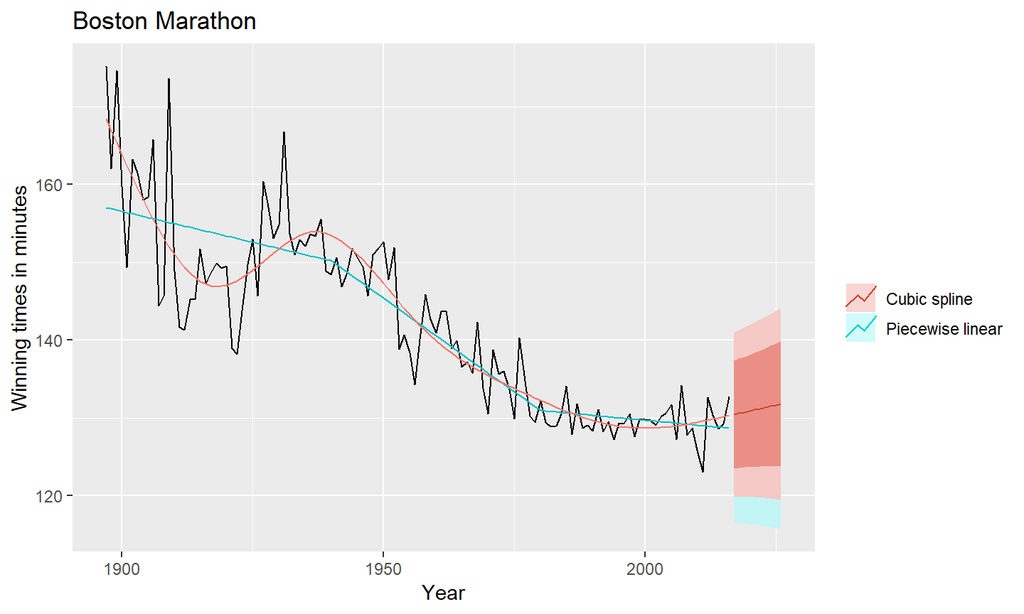

## splinef

A slightly different type of spline is provided by `splinef`

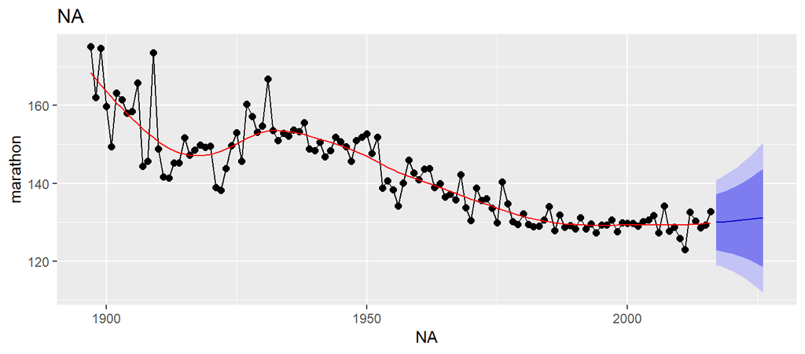

```r
fc <- splinef(marathon)
autoplot(fc)
```

## splinef

- Cubic **smoothing** splines (rather than cubic regression splines).
- Still piecewise cubic, but with many more knots (one at each observation).
- Coefficients constrained to prevent the curve becoming too “wiggly”.
- Degrees of freedom selected automatically.
- Equivalent to ARIMA(0,2,2) and Holt’s method.

## Selecting predictors and forecast evaluation

## Selecting predictors

- When there are many predictors, how should we choose which ones to use?
- We need a way of comparing two competing models.

**What not to do!**

- Plot \(y\) against a particular predictor (\(x_j\)) and if it shows no noticeable relationship, drop it.
- Do a multiple linear regression on all the predictors and disregard all variables whose \(p\) values are greater than 0.05.
- Maximize \(R^2\) or minimize MSE

## Comparing regression models

Computer output for regression will always give the \(R^2\) value. This is a useful summary of the model.

- It is equal to the square of the correlation between \(y\) and \(\hat y\).
- It is often called the ``coefficient of determination’’.
- It can also be calculated as follows: \[R^2 = \frac{\sum(\hat{y}_t - \bar{y})^2}{\sum(y_t-\bar{y})^2} \]
- It is the proportion of variance accounted for (explained) by the predictors.

## Comparing regression models

However

- \(R^2\) does not allow for ``degrees of freedom’’.
- Adding *any* variable tends to increase the value of \(R^2\), even if that variable is irrelevant.

## Cross-validation

**Cross-validation for regression**

(Assuming future predictors are known)

- Select one observation for test set, and use observations in training set. Compute error on test observation.
- Repeat using each possible observation as the test set.
- Compute accuracy measure over all errors.

## Cross-validation

**Traditional evaluation**

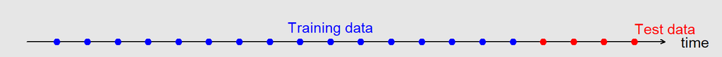

**Leave-one-out cross-validation**

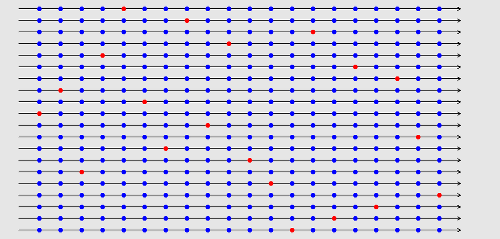

## Cross-validation

Leave-one-out cross-validation for regression can be carried out using the following steps.

- Remove observation \(t\) from the data set, and fit the model using the remaining data. Then compute the error (\(e_t^*=y_t-\hat{y}_t\)) for the omitted observation.
- Repeat step 1 for \(t=1,\dots,T\).
- Compute the MSE from \(\{e_1^*,\dots,e_T^*\}\). We shall call this the CV.

The best model is the one with minimum CV.

## Cross-validation

**Five-fold cross-validation**

- 20 observations. 4 test observations per fold

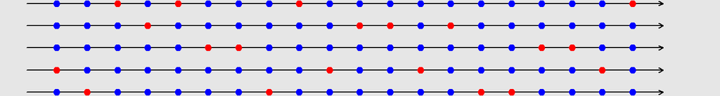

**Ten-fold cross-validation**

- 20 observations. 2 test observations per fold

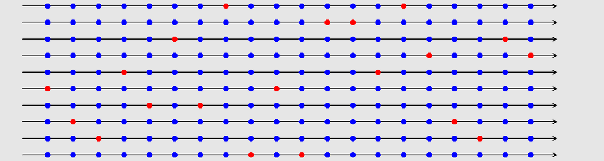

## Cross-validation

- Randomly split data into 10 parts.
- Select one part for test set, and use remaining parts as training set. Compute accuracy measures on test observations.
- Repeat for each of 10 parts
- Average over all measures.

## Akaike’s Information Criterion

where \(L\) is the likelihood and \(k\) is the number of predictors in the model.

## Corrected AIC

For small values of \(T\), the AIC tends to select too many predictors, and so a bias-corrected version of the AIC has been developed.

As with the AIC, the AIC\(_{\text{C}}\) should be minimized.

## Bayesian Information Criterion

where \(L\) is the likelihood and \(k\) is the number of predictors in the model.

- BIC penalizes terms more heavily than AIC
- Also called SBIC and SC.
- Minimizing BIC is asymptotically equivalent to leave-\(v\)-out cross-validation when \(v = T[1-1/(log(T)-1)]\).

## Choosing regression variables

**Best subsets regression**

- Fit all possible regression models using one or more of the predictors.
- Choose the best model based on one of the measures of predictive ability (CV, AIC, AICc).

**Warning!**

- If there are a large number of predictors, this is not possible.
- For example, 44 predictors leads to 18 trillion possible models!

## Choosing regression variables

**Backwards stepwise regression**

- Start with a model containing all variables.
- Try subtracting one variable at a time. Keep the model if it has lower CV or AICc.
- Iterate until no further improvement.

**Notes**

- Stepwise regression is not guaranteed to lead to the best possible model.
- Inference on coefficients of final model will be wrong.

## Cross-validation

```r
tslm(Consumption ~ Income + Production + Unemployment + Savings,
  data=uschange) %>% CV()
```

```
##           CV          AIC         AICc          BIC        AdjR2
##    0.1163477 -409.2980298 -408.8313631 -389.9113781    0.7485856
```

```r
tslm(Consumption ~ Income + Production + Unemployment,
  data=uschange) %>% CV()
```

```
##           CV          AIC         AICc          BIC        AdjR2
##    0.2776928 -243.1635677 -242.8320760 -227.0080246    0.3855438
```

```r
tslm(Consumption ~ Income + Production + Savings,
  data=uschange) %>% CV()
```

```
##           CV          AIC         AICc          BIC        AdjR2
##    0.1178681 -407.4669279 -407.1354362 -391.3113848    0.7447840
```

```r
tslm(Consumption ~ Income + Unemployment + Savings,
  data=uschange) %>% CV()
```

```
##           CV          AIC         AICc          BIC        AdjR2
##    0.1160223 -408.0941325 -407.7626408 -391.9385894    0.7456386
```

```r
tslm(Consumption ~ Production + Unemployment + Savings,
  data=uschange) %>% CV()
```

```
##           CV          AIC         AICc          BIC        AdjR2
##    0.2927095 -234.3734580 -234.0419663 -218.2179149    0.3559711
```

## Forecasting with regression

## Ex-ante versus ex-post forecasts

- *Ex ante forecasts* are made using only information available in advance.
  - require forecasts of predictors
- *Ex post forecasts* are made using later information on the predictors.
  - useful for studying behaviour of forecasting models.
- trend, seasonal and calendar variables are all known in advance, so these don’t need to be forecast.

## Scenario based forecasting

- Assumes possible scenarios for the predictor variables
- Prediction intervals for scenario based forecasts do not include the uncertainty associated with the future values of the predictor variables.

## Building a predictive regression model

- If getting forecasts of predictors is difficult, you can use lagged predictors instead. \[y_{t}=\beta_0+\beta_1x_{1,t-h}+\dots+\beta_kx_{k,t-h}+\varepsilon_{t}\]
- A different model for each forecast horizon \(h\).

## Beer production

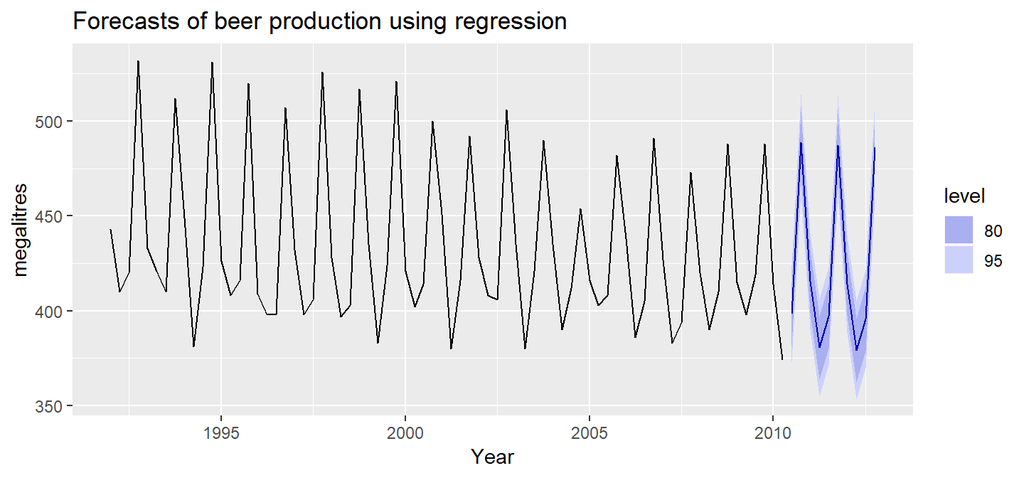

```r
beer2 <- window(ausbeer, start=1992)
fit.beer <- tslm(beer2 ~ trend + season)
fcast <- forecast(fit.beer)
autoplot(fcast) +
  ggtitle("Forecasts of beer production using regression") +
  xlab("Year") + ylab("megalitres")
```

## US Consumption

```r
fit.consBest <- tslm(
  Consumption ~ Income + Savings + Unemployment,
  data = uschange)
h <- 4
newdata <- data.frame(
    Income = c(1, 1, 1, 1),
    Savings = c(0.5, 0.5, 0.5, 0.5),
    Unemployment = c(0, 0, 0, 0))
fcast.up <- forecast(fit.consBest, newdata = newdata)
newdata <- data.frame(
    Income = rep(-1, h),
    Savings = rep(-0.5, h),
    Unemployment = rep(0, h))
fcast.down <- forecast(fit.consBest, newdata = newdata)
```

## US Consumption

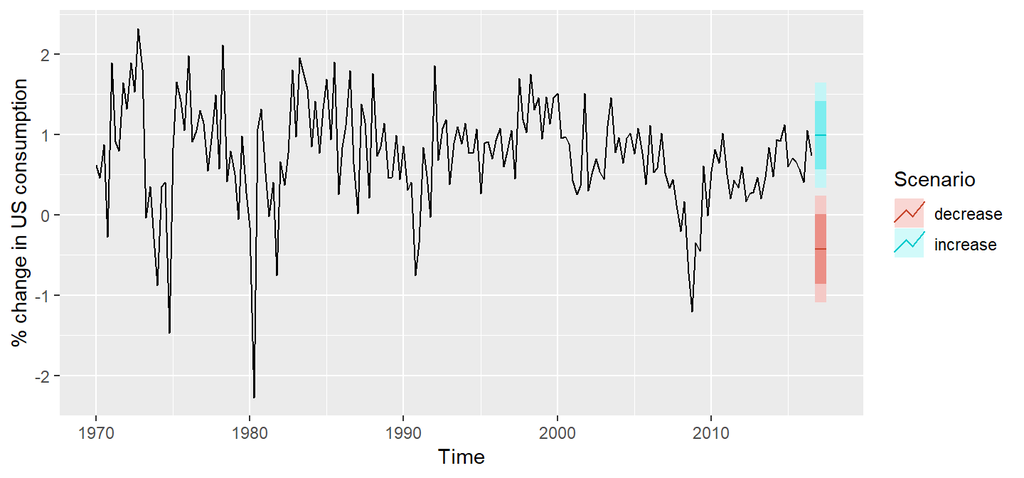

```r
autoplot(uschange[, 1]) +
  ylab("% change in US consumption") +
  autolayer(fcast.up, PI = TRUE, series = "increase") +
  autolayer(fcast.down, PI = TRUE, series = "decrease") +
  guides(colour = guide_legend(title = "Scenario"))
```

## Matrix formulation

## Matrix formulation

Let \(\bm{y} = (y_1,\dots,y_T)'\), \(\bm{\varepsilon} = (\varepsilon_1,\dots,\varepsilon_T)'\), \(\bm{\beta} = (\beta_0,\beta_1,\dots,\beta_k)'\) and \[ \bm{X} = \begin{bmatrix} 1 & x_{1,1} & x_{2,1} & \dots & x_{k,1}\\ 1 & x_{1,2} & x_{2,2} & \dots & x_{k,2}\\ \vdots & \vdots & \vdots & & \vdots\\ 1 & x_{1,T} & x_{2,T} & \dots & x_{k,T} \end{bmatrix}. \]

Then

\[\bm{y} = \bm{X}\bm{\beta} + \bm{\varepsilon}.\]

## Matrix formulation

**Least squares estimation**

Minimize: \((\bm{y} - \bm{X}\bm{\beta})'(\bm{y} - \bm{X}\bm{\beta})\)

Differentiate wrt \(\bm{\beta}\) gives

(The ``normal equation’’.)

\[ \hat{\sigma}^2 = \frac{1}{T-k-1}(\bm{y} - \bm{X}\hat{\bm{\beta}})'(\bm{y} - \bm{X}\hat{\bm{\beta}}) \]

If you fall for the dummy variable trap, \((\bm{X}'\bm{X})\) is a singular matrix.

## Likelihood

If the errors are iid and normally distributed, then \[ \bm{y} \sim \text{N}(\bm{X}\bm{\beta},\sigma^2\bm{I}). \] So the likelihood is \[ L = \frac{1}{\sigma^T(2\pi)^{T/2}}\exp\left(-\frac1{2\sigma^2}(\bm{y}-\bm{X}\bm{\beta})'(\bm{y}-\bm{X}\bm{\beta})\right) \] which is maximized when \((\bm{y}-\bm{X}\bm{\beta})'(\bm{y}-\bm{X}\bm{\beta})\) is minimized.

## Multiple regression forecasts

where \(\bm{x}^*\) is a row vector containing the values of the predictors for the forecasts (in the same format as \(\bm{X}\)).

- This ignores any errors in \(\bm{x}^*\).
- 95% prediction intervals assuming normal errors: \[\hat{y}^* \pm 1.96 \sqrt{\text{Var}(y^*| \bm{X},\bm{x}^*)}.\]

## Multiple regression forecasts

where \(\bm{H} = \bm{X}(\bm{X}'\bm{X})^{-1}\bm{X}'\) is the ``hat matrix’’.

**Leave-one-out residuals**

Let \(h_1,\dots,h_T\) be the diagonal values of \(\bm{H}\), then the cross-validation statistic is

where \(e_t\) is the residual obtained from fitting the model to all \(T\) observations.

## Correlation, causation and forecasting

## Correlation is not causation

- When \(x\) is useful for predicting \(y\), it is not necessarily causing \(y\).
- e.g., predict number of drownings \(y\) using number of ice-creams sold \(x\).
- Correlations are useful for forecasting, even when there is no causality.
- Better models usually involve causal relationships (e.g., temperature \(x\) and people \(z\) to predict drownings \(y\)).

## Multicollinearity

In regression analysis, multicollinearity occurs when:

- Two predictors are highly correlated (i.e., the correlation between them is close to \(\pm1\)).
- A linear combination of some of the predictors is highly correlated with another predictor.
- A linear combination of one subset of predictors is highly correlated with a linear combination of another subset of predictors.

## Multicollinearity

If multicollinearity exists

- the numerical estimates of coefficients may be wrong (worse in Excel than in a statistics package)
- don’t rely on the \(p\)-values to determine significance.
- there is no problem with model *predictions* provided the predictors used for forecasting are within the range used for fitting.
- omitting variables can help.
- combining variables can help.

## Outliers and influential observations

**Things to watch for**

- *Outliers*: observations that produce large residuals.
- *Influential observations*: removing them would markedly change the coefficients. (Often outliers in the \(x\) variable).
- *Lurking variable*: a predictor not included in the regression but which has an important effect on the response.
- Points should not normally be removed without a good explanation of why they are different.